# Lab 06: Leverage

Billy Fang

October 5, 2017

```r
library(car)
data(Duncan)
```

# Review of yesterday’s lecture

**Relevant reading: 11.1, 11.2, 11.8.1-2**

Hat matrix:
$$H := X(X^\top X)^{-1} X^\top$$
Fitted values:
$$\widehat{y} = Hy$$

Writing out the above yields
$$\begin{align}
\widehat{y}_1 &= h_{1,1} y_1 + h_{1,2} y_2 + \cdots + h_{1,n} y_n
\\
&\vdots
\\
\widehat{y}_n &= h_{n,1} y_1 + h_{n,2} y_2 + \cdots + h_{n,n} y_n.
\end{align}$$

How much does $y_2$ contribute to all the fitted values $\widehat{y}_1, \ldots, \widehat{y}_n$? Could consider
$$h_{12}^2 + h_{22}^2 + h_{32}^2 + \cdots + h_{n2}^2.$$
By symmetry of $H$, this can be viewed as the dot product of the second row of $H$ with the second column of $H$, which is the $(2,2)$ entry of $H^2$. By idempotence of $H$, we have $H^2=H$ so the above quantity is simply $h_2 \equiv h_{2,2}$. More generally, how much $y_i$ contributes to all the fitted values $\widehat{y}_1, \ldots, \widehat{y}_n$ can be measured by
$$h_i \equiv h_{ii} = h_{1,i}^2 + \cdots + h_{n,i}^2.$$
Furthermore we can go back to the formula $H = X(X^\top X)^{-1} X^\top$ and note that the $j$th diagonal entry can be written as
$$h_i = x_i^\top (X^\top X)^{-1} x_i,\tag{1}$$
where $x_i^\top$ is the $i$th row of the design matrix. We call this **leverage** of the $i$th observation. As emphasized in lecture, this only depends on the observed explanatory variables $x_1, \ldots, x_n$.

1. $h_i$ measures how far $x_i$ (explanatory variables for $j$th observation) is from the other observed explanatory variables. (See discussion below.)
2. $h_i$ measures how much *potential* the $i$th subject has to influence the the fitted line/plane.

Does this quantity (1) look familiar?

Let $X$ be $n \times (p+1)$ have an intercept column and have full column rank. Review the following facts from lecture:

- $h_1 + \cdots + h_n = p + 1$
- $\text{Var}(\widehat{y}_i) = \sigma^2 h_i$
- $\text{Var}(e_i) = \sigma^2 (1 - h_i)$, where $e_i := y_i - \widehat{y}_i$ is the $i$th residual
- $\frac{1}{n} \le h_i \le 1$ (in general if there is no intercept column in $X$, then $0 \le h_i \le 1$)
- when $h_i$ is large (close to $1$), then $\widehat{y}_i$ is close to $y_i$

# A distance by any other name would smell as sweet

[figure not shown]

Let
$$S := \frac{1}{n-1} \sum_{j=1}^n (x_j - \overline{x})(x_j - \overline{x})^\top
= \frac{1}{n-1} (X^*)^\top (X^*)$$
be the sample covariance matrix of the explanatory variables. Remember, here $x_j^\top$ denotes the $j$th row of $X$ (the explanatory variables for the $j$th person), and $\overline{x} := \frac{1}{n} \sum_{i=1}^n x_i$. Note that $X^*$ is $n \times p$ and whose columns are the non-intercept columns of $X$ centered around their mean.

[If we think of the $x_i$ as i.i.d. variables coming from some distribution, then the covariance matrix of such a random vector $x$ is $\text{Cov}(x) = \mathbb{E}[(x - \mathbb{E}[x])(x - \mathbb{E}[x])^\top]$. By comparing this with the definition of $S$, we see that $S$ is an estimate of $\text{Cov}(x)$.]

Using $S$ can define a norm (“length” or “size”) for any vector $v \in \mathbb{R}^n$ by
$$\sqrt{v^\top S^{-1} v}.\tag{$*$}$$
Special cases:

- When $S = I_n$ then this is simply
  $$\sqrt{v^\top v} = \sqrt{v_1^2 + \cdots + v_n^2} = \|v\|.$$
- When $S$ is diagonal with diagonal elements $s_1, \ldots, s_n$, then this is
  $$\sqrt{\frac{v_1^2}{s_1} + \cdots + \frac{v_n^2}{s_n}}.$$

Consider the following examples for $S$.

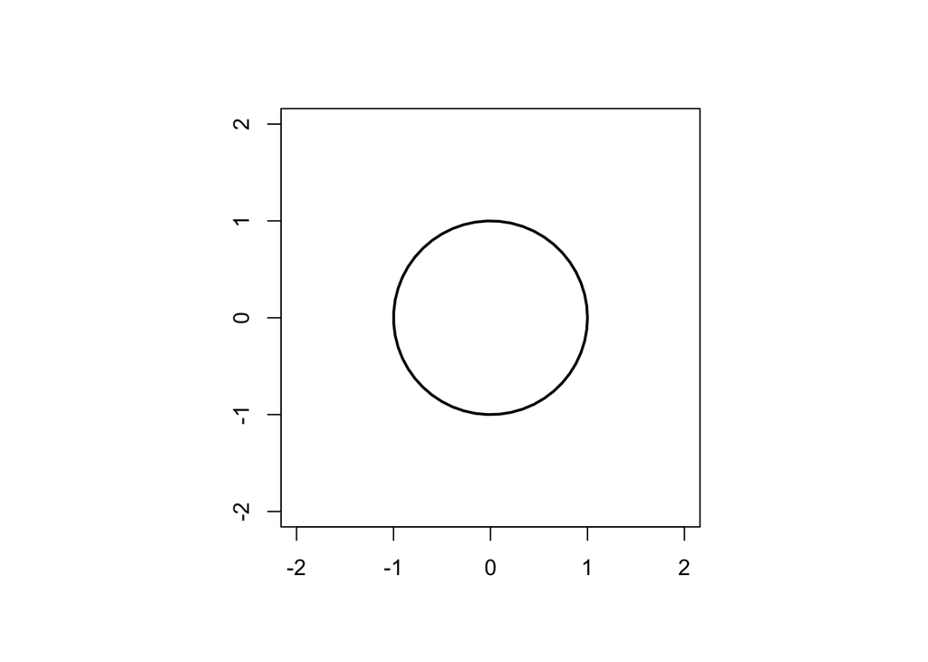

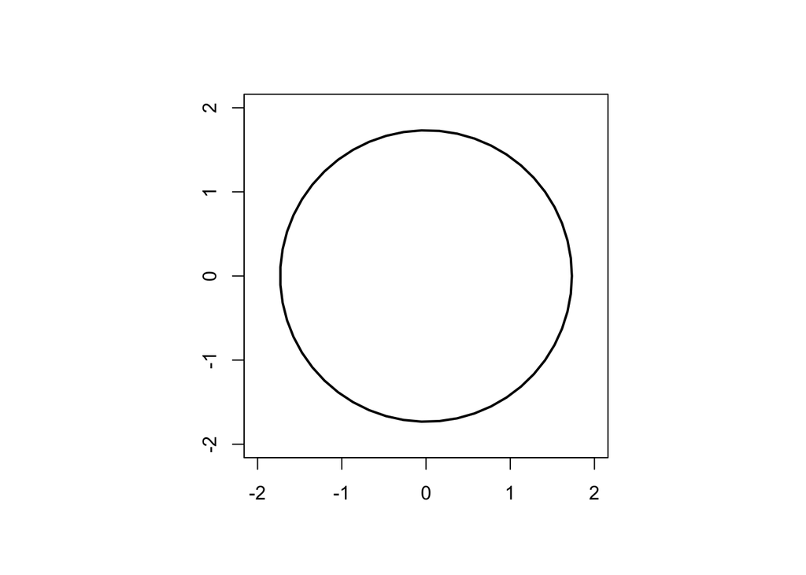

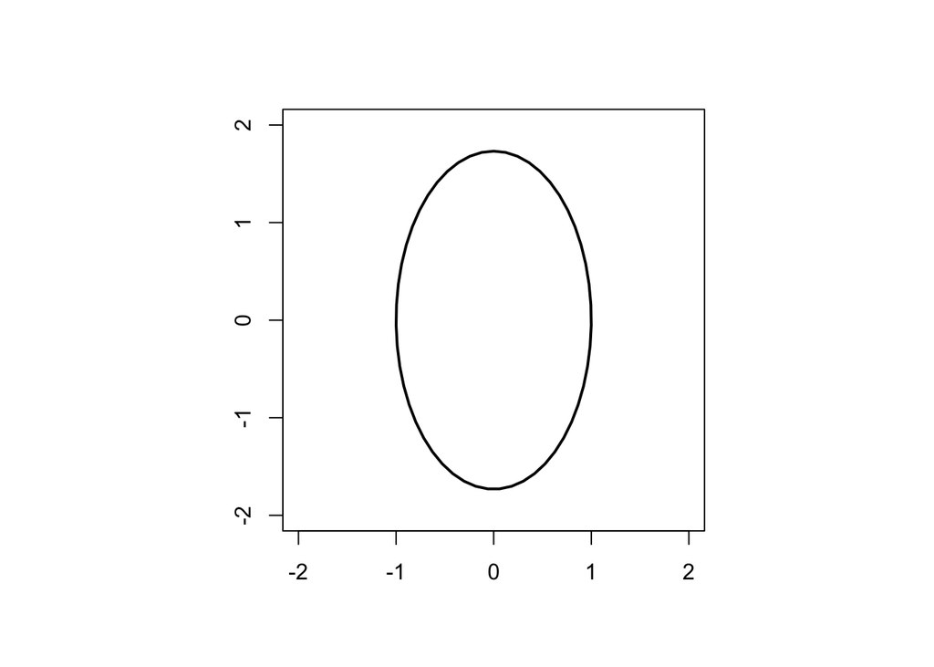

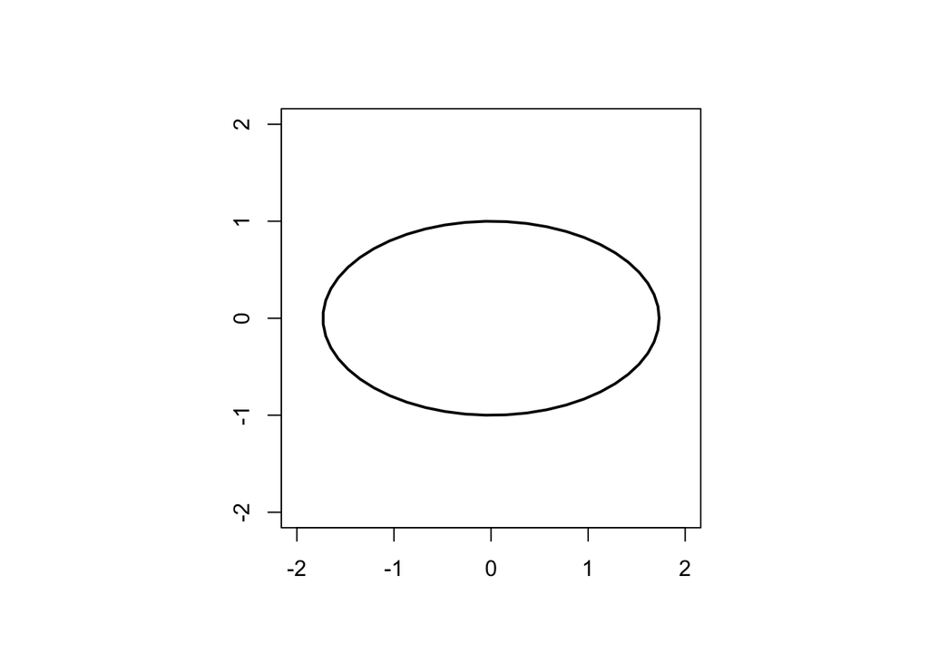

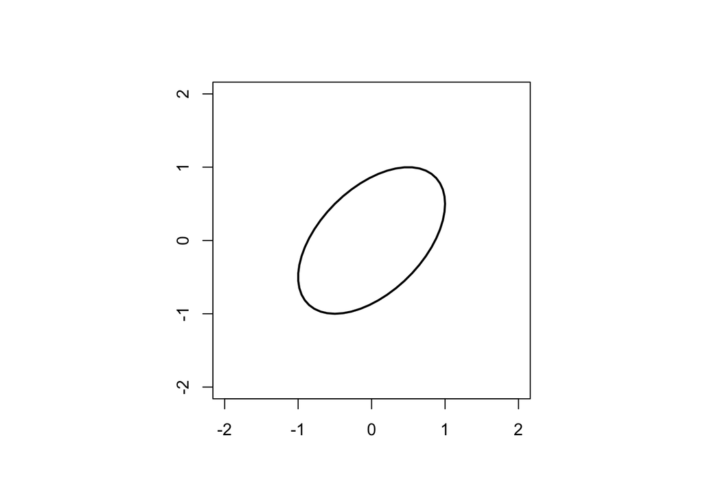

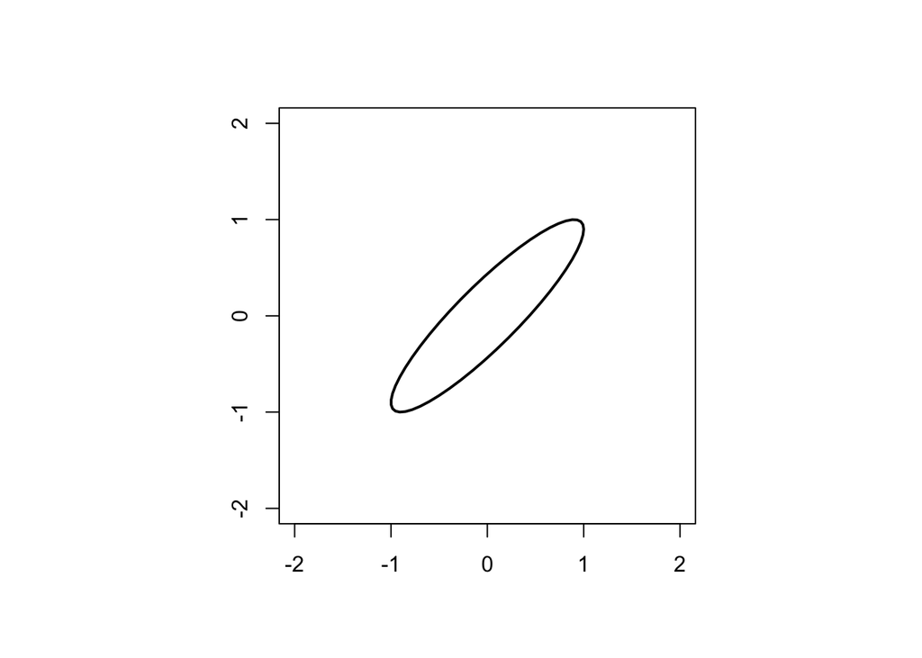

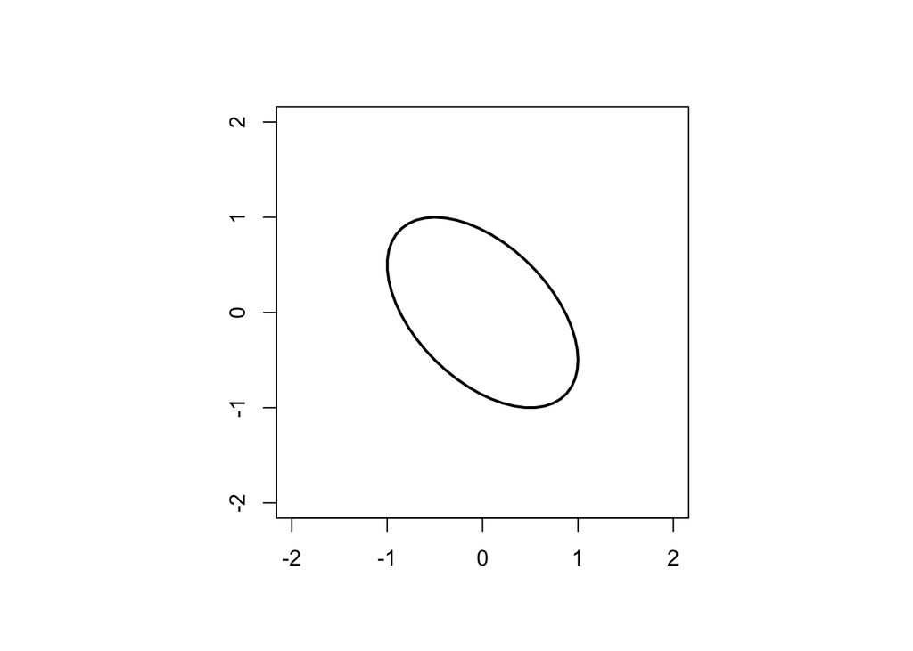

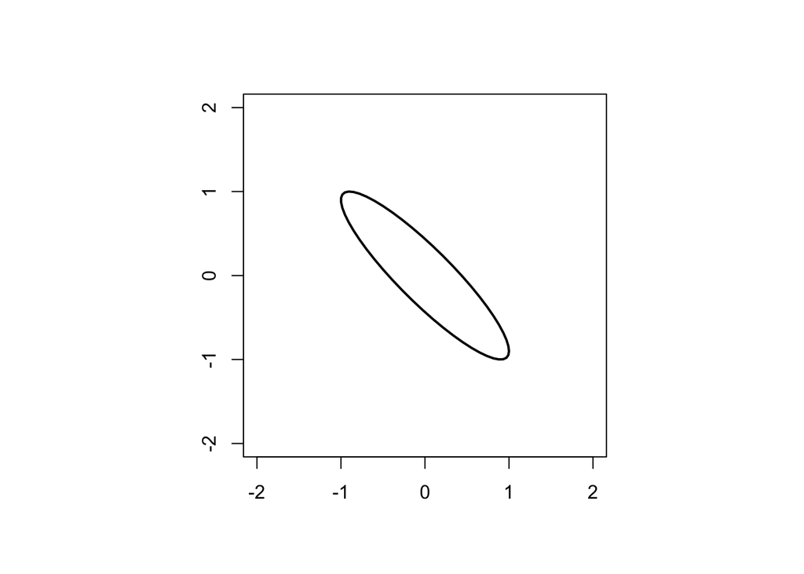

The **Mahalanobis distance** for the $i$th observation in the design matrix $X$ is
$$\sqrt{(x_i - \overline{x})^\top S^{-1} (x_i - \overline{x})},$$
where $S^{-1}$ is as defined above. It measures how far $x_i$ ($i$th data point) is from the centroid $\overline{x}$ using this norm as defined in ($*$) above.

How is this related to the leverage $h_i = x_i^\top (X^\top X)^{-1} x_i$? Your lecture notes mention the following equality.
$$\underbrace{(x_i - \overline{x})^\top S^{-1} (x_i - \overline{x})}_{\Gamma_i} = (n - 1) (h_i - \frac{1}{n})$$
or equivalently
$$h_i = \frac{1}{n} + \underbrace{(x_i - \overline{x})^\top [(X^*)^\top (X^*)]^{-1} (x_i - \overline{x})}_{\frac{1}{n-1} \Gamma_i}$$
(See page 290 of the textbook.) Again, what does this relationship between [squared] Mahalanobis distance $\Gamma_i$ and leverage $h_i$ imply qualitatively?

Optional proof: If we take the design matrix $X$ (with intercept column and full column rank) and center the non-intercept columns (i.e. replacing them with the columns of $X^*$), then the column space does not change, so the hat matrix $H = X(X^\top X)^{-1} X^\top$. So without loss of generality we may assume
$$X = \left[\begin{array}{c|ccc}
1 & \ & & \\\
\vdots & & X^*\\
1
\end{array}\right].$$
Then
$$X^\top X = \begin{bmatrix}
n\\ & (X^*)^\top (X^*)
\end{bmatrix}$$
is block diagonal (because each column of $X^*$ sums to zero), so its inverse can be found by inverting each block. Finally, the $i$th diagonal element of $H$ is
$$h_i
= x_i^\top (X^\top X)^{-1} x_i
= \begin{bmatrix}1 & x_i - \bar{x}\end{bmatrix}
\begin{bmatrix}
\frac{1}{n} \\ & [(X^*)^\top (X^*)]^{-1}
\end{bmatrix}
\begin{bmatrix}1 \\ x_i - \bar{x}\end{bmatrix}$$
which yields the result.

# Example: Duncan’s prestige data

*Reproducing Figure 11.5 in section 11.2.*

```r
head(Duncan)
```

```
##            type income education prestige
## accountant prof     62        86       82
## pilot      prof     72        76       83
## architect  prof     75        92       90
## author     prof     55        90       76
## chemist    prof     64        86       90
## minister   prof     21        84       87
```

```r
mod <- lm(prestige ~ income + education, data=Duncan)
X <- cbind(1, Duncan[,c("income", "education")])
X <- unname(as.matrix(X))
hat(X) # hat function gives leverage values
```

```
##  [1] 0.05092832 0.05732001 0.06963699 0.06489441 0.05132528 0.17305816
##  [7] 0.06449273 0.08785184 0.05439356 0.05932285 0.04678919 0.07925452
## [13] 0.07765314 0.07828447 0.08258799 0.19454165 0.04325517 0.04325478
## [19] 0.02628592 0.07224159 0.07975595 0.02412984 0.03132603 0.03270490
## [25] 0.04550181 0.04089141 0.26908963 0.03630630 0.04640845 0.06920206
## [31] 0.04969910 0.08030881 0.06065016 0.06445993 0.05858763 0.04959881
## [37] 0.04844212 0.04785227 0.06565969 0.05370328 0.05695616 0.04746090
## [43] 0.06866938 0.02468161 0.07058120
```

```r
# manually computing hat values
H <- X %*% solve(t(X) %*% X) %*% t(X)
diag(H)
```

```
##  [1] 0.05092832 0.05732001 0.06963699 0.06489441 0.05132528 0.17305816
##  [7] 0.06449273 0.08785184 0.05439356 0.05932285 0.04678919 0.07925452
## [13] 0.07765314 0.07828447 0.08258799 0.19454165 0.04325517 0.04325478
## [19] 0.02628592 0.07224159 0.07975595 0.02412984 0.03132603 0.03270490
## [25] 0.04550181 0.04089141 0.26908963 0.03630630 0.04640845 0.06920206
## [31] 0.04969910 0.08030881 0.06065016 0.06445993 0.05858763 0.04959881
## [37] 0.04844212 0.04785227 0.06565969 0.05370328 0.05695616 0.04746090
## [43] 0.06866938 0.02468161 0.07058120
```

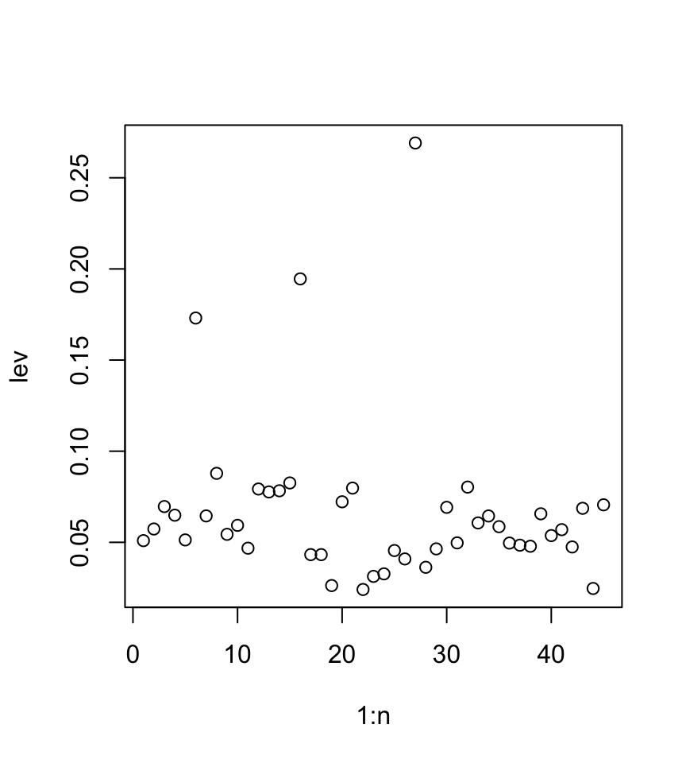

```r
lev <- diag(H)
n <- dim(Duncan)[1]
p <- 2
plot(1:n, lev)
```

```r
lev.sorted <- sort(lev, decreasing=T, index.return=T)
lev.sorted$x[1:3]
```

```
## [1] 0.2690896 0.1945416 0.1730582
```

```r
rownames(Duncan)[lev.sorted$ix[1:3]]
```

```
## [1] "RR.engineer" "conductor"   "minister"
```

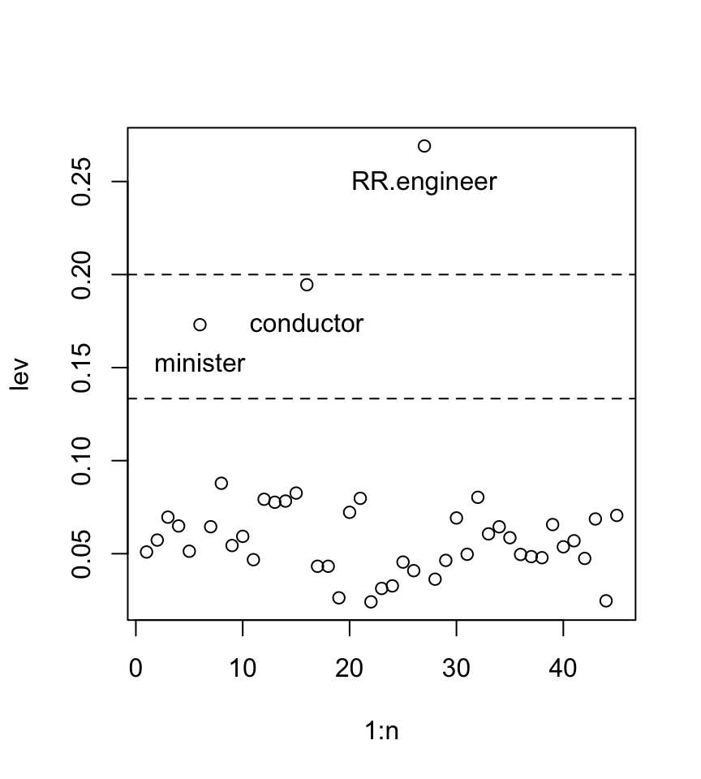

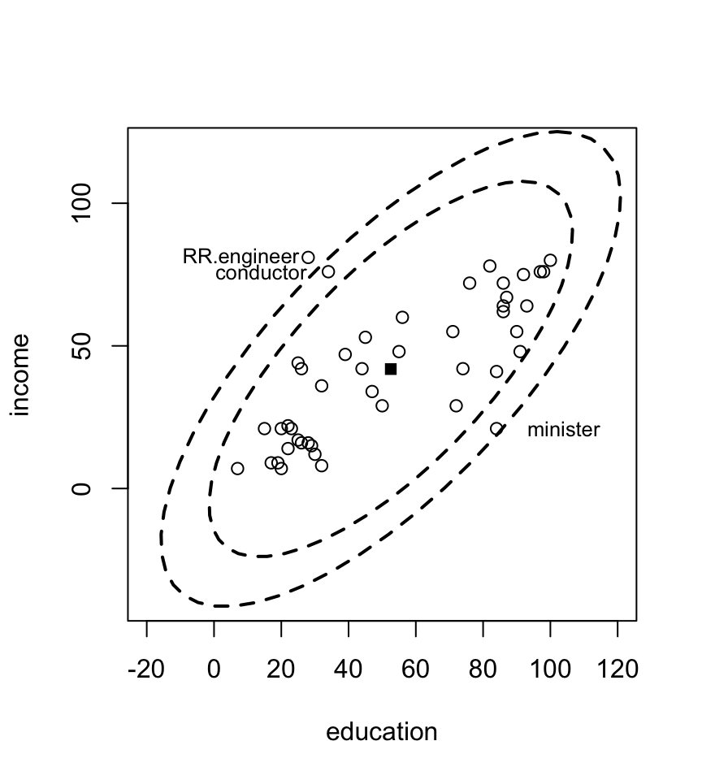

```r
plot(1:n, lev)
for(i in lev.sorted$ix[1:3]) {
  text(i, lev[i]-0.02, rownames(Duncan)[i])
}
hbar <- (p+1)/n
abline(h=2*hbar, lty=2)
abline(h=3*hbar, lty=2)

plot(Duncan$education, Duncan$income, xlim=c(-20, 120), ylim=c(-40, 120), xlab="education", ylab="income")
i = lev.sorted$ix[1]
text(Duncan$education[i]-20, Duncan$income[i], rownames(Duncan)[i], cex=0.8)
i = lev.sorted$ix[2]
text(Duncan$education[i]-20, Duncan$income[i], rownames(Duncan)[i], cex=0.8)
i = lev.sorted$ix[3]
text(Duncan$education[i]+20, Duncan$income[i], rownames(Duncan)[i], cex=0.8)
centroid <- c(mean(Duncan$education), mean(Duncan$income))
points(centroid[1], centroid[2], pch=15)
Xstar <- scale(X[,2:3], scale=F) # centering columns
A <- (t(Xstar) %*% Xstar)
ellipse(centroid, shape=A, radius=sqrt(2*hbar - 1/n), col=1, lty=2, center.cex=0)
ellipse(centroid, shape=A, radius=sqrt(3*hbar - 1/n), col=1, lty=2, center.cex=0)
```

# Added variable plots: residuals vs. residuals

**Relevant reading: 11.6.1** (also see the note I uploaded to bCourses before the midterm)

For each subject $i=1, \ldots, n$ we have a response variable $y_i$ and explanatory variables $x_{i1}, \ldots, x_{ip}$. We can do a least squares fit to get coefficients $\widehat{\beta}_0, \ldots, \widehat{\beta}_p$ that give fitted values
$$\widehat{y}_i = \widehat{\beta}_0 + \widehat{\beta}_1 x_{i1} + \cdots + \widehat{\beta}_p x_{ip}.$$
Suppose instead we do the following three regressions. (Note here $x_j$ denotes columns of $X$.)

1. Regress $y$ onto all variables except the first (columns $x_2, \ldots, x_p$) to get fitted value $\widetilde{\widehat{y}}$ and residuals $y - \widetilde{\widehat{y}}$.
2. Regress the first variable’s column $x_1$ on the other variables (columns $x_2, \ldots, x_p$) to get fitted value $\widehat{x}_1$ and residual $x - \widehat{x}$.
3. Do a simple regression of the residuals $y - \widetilde{\widehat{y}}$ onto the residuals $x - \widehat{x}$.

A plot of the last regression is called an **added variable plot** or a **partial regression plot**.

Why not just just plot $y$ against $x_1$? Still contains effect of other variables, not useful for assessing the relationship between $x_1$ and $y$ *holding all other variables constant*. For example, strong correlation between $x_1$ and the other variables may cause a $y$ vs. $x_1$ plot to show a negative trend, even if there is a true linear model with $\beta_1 > 0$. [See [this stackexchange answer](https://stats.stackexchange.com/a/125575) for more detail.]

The regressions (a) and (b) try extract the parts of $y$ and $x_1$ that are not explained by the other variables $x_2, \ldots, x_p$, and then (c) views this relationship between $y$ and $x_1$, *given the effect of the other variables.*

We have the following interesting properties.

1. The slope from the simple regression (c) is precisely $\widehat{\beta}_1$ from the original multiple regression. [This simple regression also has zero intercept.]
2. The residuals from the simple regression (c) are the same as the residuals from the original multiple regression.
3. *Useful for detecting points of high leverage and/or high influence.*
4. Since the residuals are the same, may be good for identifying violations of model assumptions (heteroscedasticity, nonlinearity, etc.)

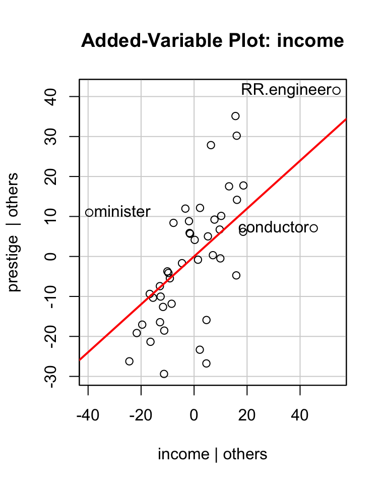

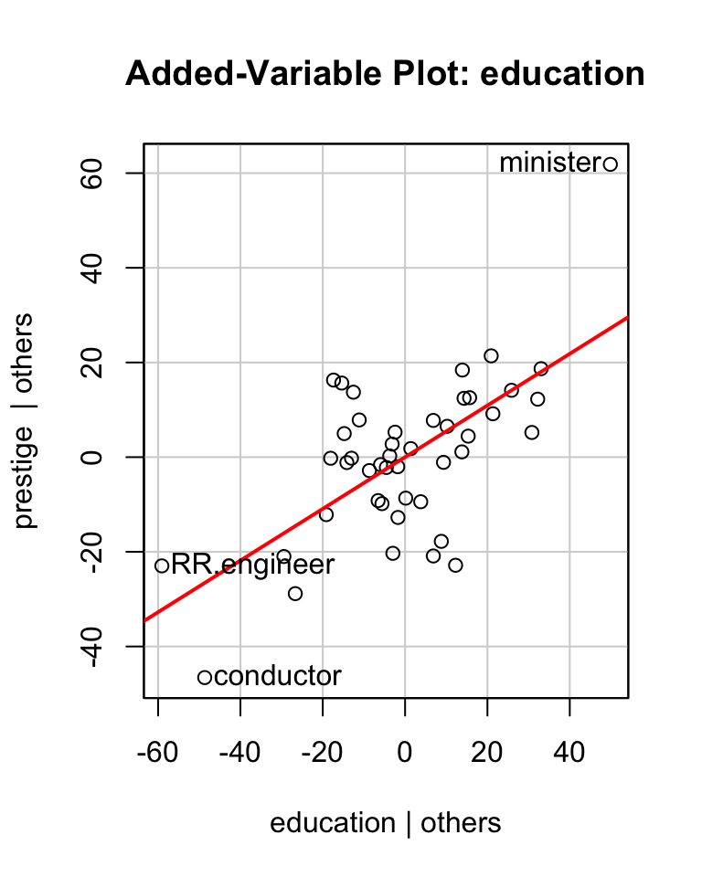

```r
avPlot(mod, "income", id.method="x", id.n=3)
avPlot(mod, "education", id.method="x", id.n=3)
```

How to interpret high leverage points on such plots?

```r
coef(mod)
```

```
## (Intercept)      income   education
##  -6.0646629   0.5987328   0.5458339
```

```r
rownames(Duncan)[lev.sorted$ix[1:3]]
```

```
## [1] "RR.engineer" "conductor"   "minister"
```

```r
Duncan_del <- Duncan[-lev.sorted$ix[2:3],]
mod_del <- lm(prestige ~ income + education, data=Duncan_del)
coef(mod_del)
```

```
## (Intercept)      income   education
##  -6.4089856   0.8673986   0.3322408
```

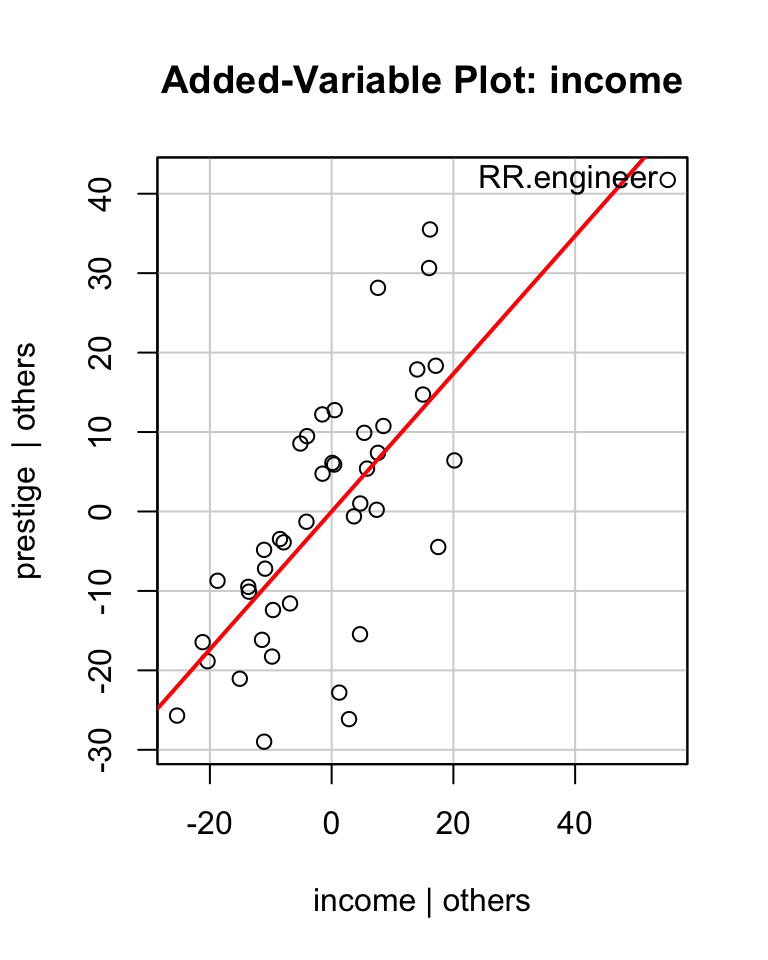

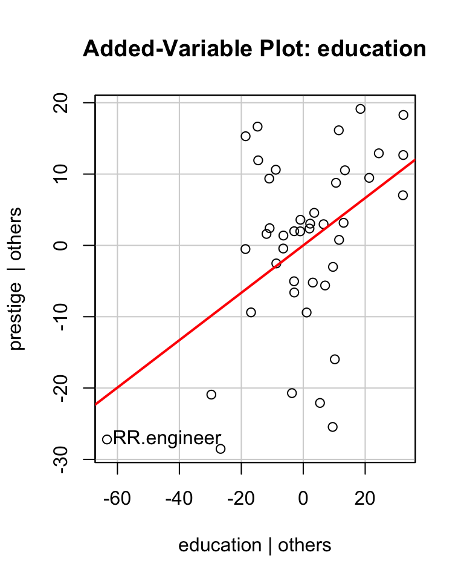

```r
avPlot(mod_del, "income", id.method="x", id.n=1)
avPlot(mod_del, "education", id.method="x", id.n=1)
```

# Component plus residuals plot

**Relevant reading: 12.3**

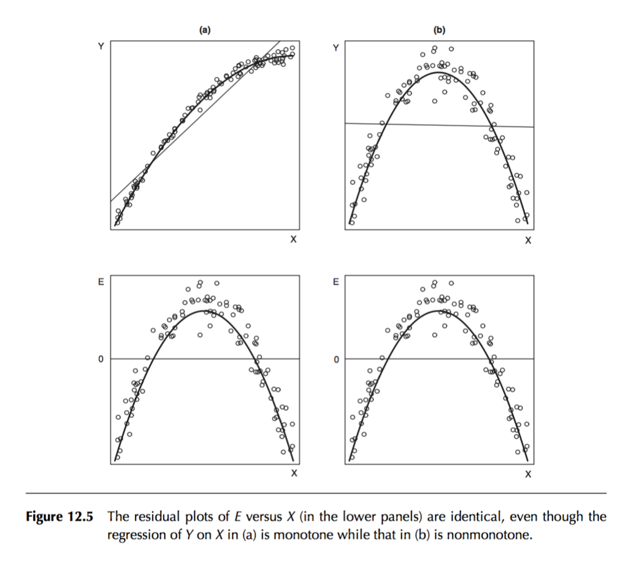

Residual plots are not enough to identify the type of nonlinearity. Plot (a) is an example of monotone might be fixed by using $Y = \alpha + \beta \sqrt{X} + \epsilon$, while (b) might be fixed by $Y = \alpha + \beta_1 X + \beta_2 X^2 + \epsilon$, but both have the same residual plots.

Added variable plots can also show nonlinearity, but are not useful for locating a transformation to correct it, since it adjusts $X_j$ after accounting for the other variables, but it is the unadjusted $X_j$ that is transformed.

**Component plus residual** plots (a.k.a. partial residual plots) offer a useful alternative. (But they are not as suitable for analyzing leverage and influence on coefficients.)

We define the **partial residuals for the $j$th explanatory variable** by
$$\begin{align}
e^{(j)}_i &= e_i + \widehat{\beta}_j x_{ij}
\\
&= [y_i - (\widehat{\beta}_0 + \widehat{\beta}_1 x_{i1} + \cdots + \widehat{\beta}_p x_{ip})] + \widehat{\beta}_j x_{ij}
\end{align}$$

(Add back the linear component)

The component plus residual plot is the plot of $e^{(j)}$ vs $x_j$.

```r
data("SLID")
SLID <- na.omit(SLID)
mod <- lm(log(wages) ~ sex + age + education, data=SLID)
coef(mod)
```

```
## (Intercept)     sexMale         age   education
##  1.12018663  0.22425674  0.01765090  0.05493486
```

```r
summary(mod)$r.squared
```

```
## [1] 0.3094527
```

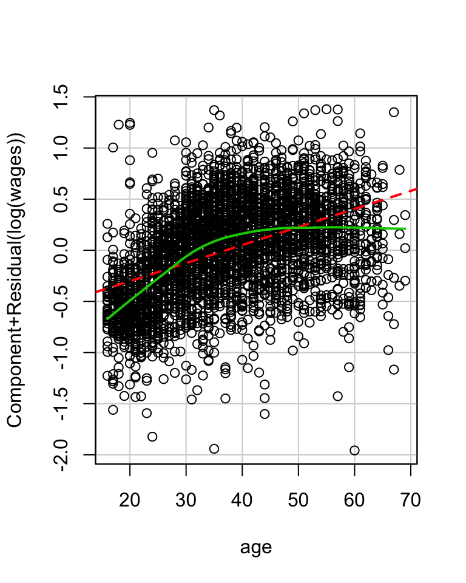

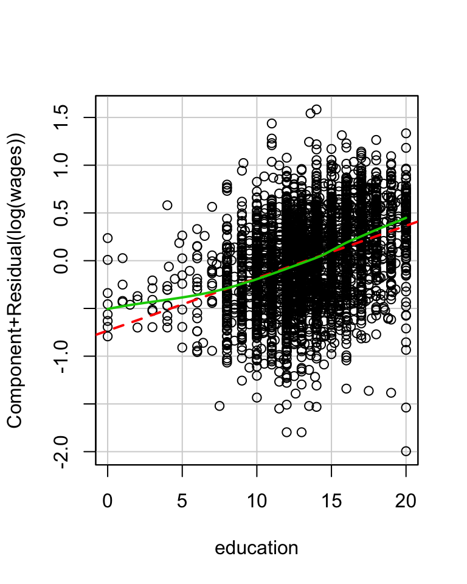

```r
crPlot(mod, variable="age")
crPlot(mod, variable="education")
```

Can suggest how to transform variables.

```r
mod2 <- lm(log(wages) ~ sex + age + I(age^2) + I(education^2), data=SLID)
coef(mod2)
```

```
##    (Intercept)        sexMale            age       I(age^2) I(education^2)
##   0.3898309249   0.2215444630   0.0834579140  -0.0008578935   0.0017642484
```

```r
summary(mod2)$r.squared
```

```
## [1] 0.3837784
```

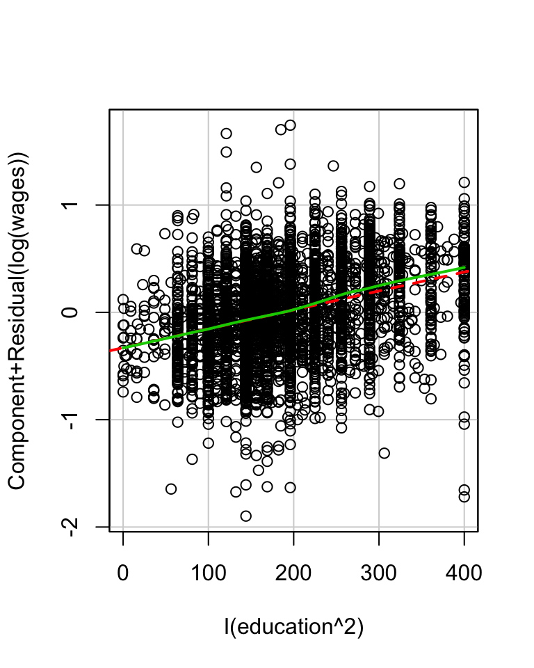

```r
#crPlot(mod2, variable="age")
crPlot(mod2, variable="I(education^2)")
```